# Homework 1

Sha Tao

September 17, 2018

Problem 1_1 The chunk below creates a data frame with four different vectors, and tries to take mean of them.

```r
set.seed(1)

# Create a data frame
data1 = tibble(

  # Create a random sample of size 10 from a uniform [0, 5] distribution
  vec_unif = runif(10, min = 0, max = 5),

  # Create a logical vector indicating whether elements of the sample are greater than 2
  vec_logical = vec_unif > 2,

  # Create a (length-10) character vector
  vec_char = c("My", "name", "is", "Sha", "Tao", "and", "I", "like", "Data", "Science"),

  # Create a (length-10) factor vector
  vec_factor = factor(c("low", "low", "low", "high", "high", "low", "low", "low", "high", "high"))
)

# Print data1
data1
```

```
## # A tibble: 10 x 4
##    vec_unif vec_logical vec_char vec_factor
##       <dbl> <lgl>       <chr>    <fct>
##  1    1.33  FALSE       My       low
##  2    1.86  FALSE       name     low
##  3    2.86  TRUE        is       low
##  4    4.54  TRUE        Sha      high
##  5    1.01  FALSE       Tao      high
##  6    4.49  TRUE        and      low
##  7    4.72  TRUE        I        low
##  8    3.30  TRUE        like     low
##  9    3.15  TRUE        Data     high
## 10    0.309 FALSE       Science  high
```

```r
# Try to take the mean of the numeric variable
mean(data1$vec_unif)
```

```
## [1] 2.757569
```

```r
# Try to take the mean of the logical variable
mean(data1$vec_logical)
```

```
## [1] 0.6
```

```r
# mean(data1$vec_char) doesn't work
# mean(vec_factor) doesn't work
```

The first two vectors work because a uniform [0, 5] distribution is numeric, and “true” and “false” in logical vectors are treated as 1 and 0.  
Means cannot be taken from the character vector and factor vector.  
Problem 1_2 The chunk below converts variables from one type to another.

```r
#applies the as.numeric function to the logical, character, and factor variables
as.numeric(data1$vec_logical)
as.numeric(data1$vec_char)
as.numeric(data1$vec_factor)
```

[output not shown]

logical vector can be convert to numeric, and “true” and “flase”" are treated as 1 and 0.  
For factor vectors, R re-orders the factors alphabetically, and assigns numeric numbers to each level. In my case, it assigns 1 to “high” and 2 to “low”.“  
Function as.numeric cannot treat character vector in my case and it returns 10”NA“s. However, if I use number”1“,”2" as my character vector, then it will return as numeric vector 1, 2.  
Problem 1_3 The chunk below does a two-step converting.

```r
# Convert character variable from character to factor to numeric
as.numeric(as.factor(data1$vec_char))
```

```
##  [1]  6  7  4  9 10  1  3  5  2  8
```

```r
# Convert factor variable from factor to character to numeric
as.numeric(as.character(data1$vec_factor))
```

```
##  [1] NA NA NA NA NA NA NA NA NA NA
```

In the first case, function as.factor converts my character vector to a factor vector. Then function as.numeric reorders the factors alphabetically, and assigns numeric numbers to each level.  
In the second case, function as.character converts my factor vector to a character vector, thus cannot be treated and returns 10 “NA”s.  
Problem 2_1 The chunks below creates a data frame for later plotting.

```r
# Create a random sample x of size 1000 from a standard Normal distribution
set.seed(1)
x = rnorm(1000)

# Create a random sample y of size 1000 from a standard Normal distribution
set.seed(2)
y = rnorm(1000)

# Create a data frame
data2 = tibble(
  x,
  y,

  # Create a logical vector indicating whether the x + y > 0
  xy_logical = x + y > 0,

  # Create a numeric vector by coercing the above logical vector
  xy_numeric = as.numeric(xy_logical),

  # Create a factor vector created by coercing the above logical vector
  xy_factor = as.factor(xy_numeric)
)
```

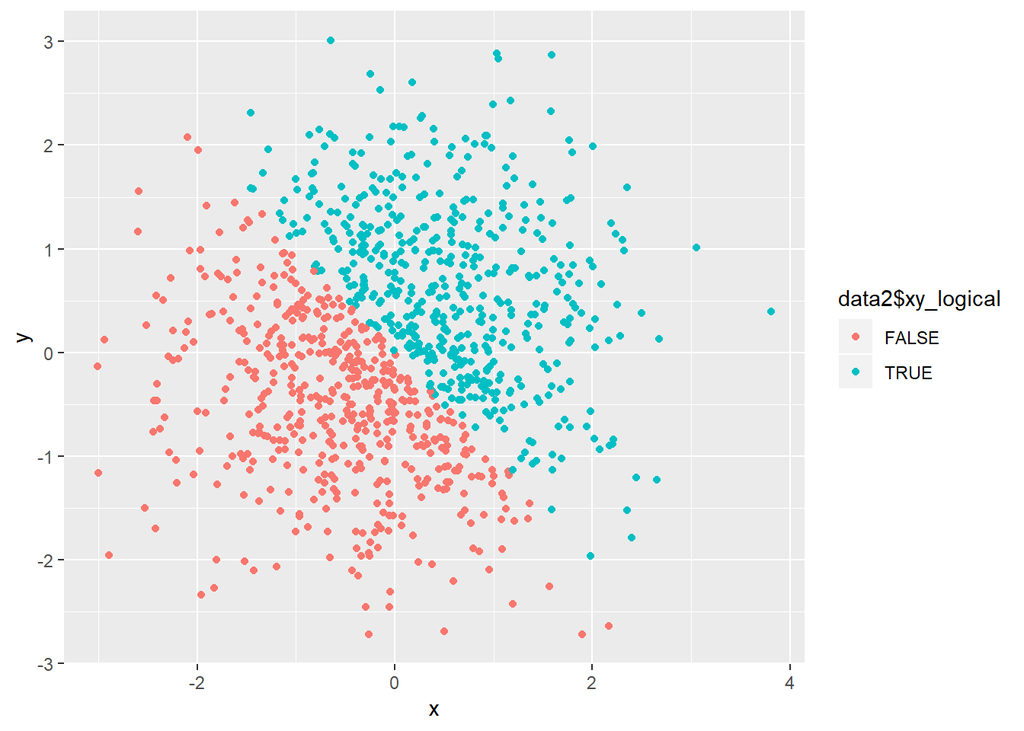

```r
# Make a scatterplot of y vs x,  color points using the logical variable
plot_logical = ggplot(data2, aes(x, y, color = data2$xy_logical)) +
        geom_point()
plot_logical
```

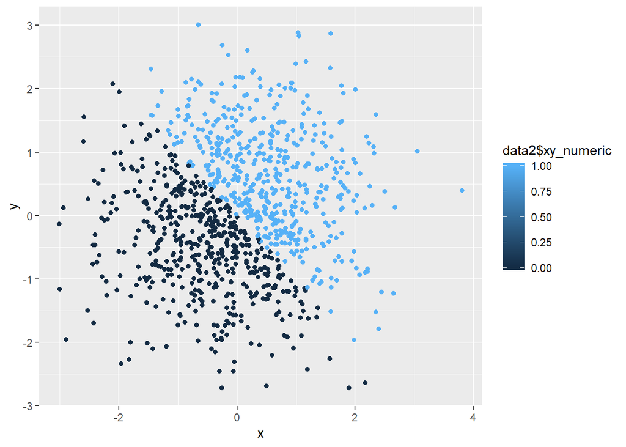

```r
# Make a scatterplot of y vs x,  color points using the numeric variable
plot_numeric = ggplot(data2, aes(x, y, color = data2$xy_numeric)) +
        geom_point()
plot_numeric
```

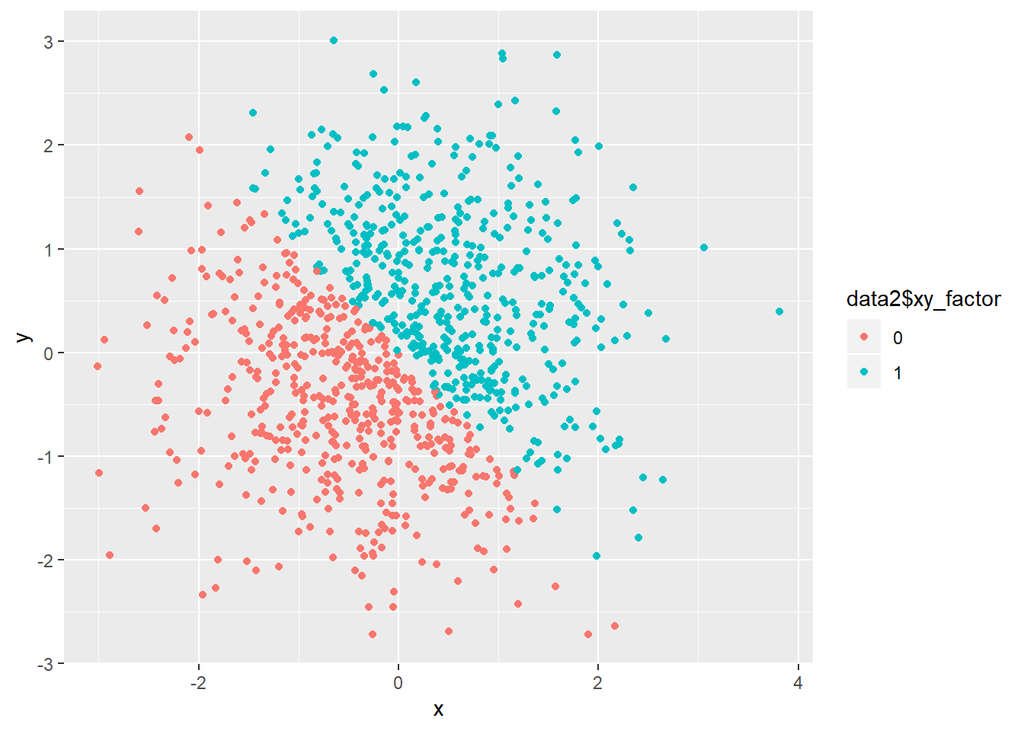

```r
# Make a scatterplot of y vs x,  color points using the factor variable
plot_factor = ggplot(data2, aes(x, y, color = data2$xy_factor)) +
        geom_point()
plot_factor
```

```r
# Save the first plot
ggsave("plot_logical.png", plot_logical)
```

Since x and y are both random samples from standard normal distribution, the boundary between whether x + y > 0 follows the function y = -x. Since the numeric vector is converted from the logical vector, and the factor vector is converted from numeric vector, they all contains two values, and the plots shows the same pattern.